# Preprocessing_and_Linear_Regression

**Importing libraries:**

```python
import pandas as pd
import numpy as np
from sklearn.model_selection import train_test_split, KFold, cross_val_score
from sklearn.linear_model import LinearRegression
import seaborn as sns
from matplotlib import pyplot as plt
import matplotlib
matplotlib.use('Agg')
import matplotlib.pyplot as plt
matplotlib.style.use('ggplot')
```

**Load the cleaned train data:**

```python
df = pd.read_csv('../data/train_clean.csv')
```

**Describe the basic format:**

```python
df.shape
```

```
(2048, 36)
```

```python
df.dtypes
```

```
Unnamed: 0        int64
ms_subclass       int64
ms_zoning         int64
street            int64
alley             int64
land_contour      int64
utilities         int64
lot_config        int64
neighborhood      int64
condition_1       int64
bldg_type         int64
house_style       int64
overall_qual      int64
exter_qual        int64
foundation        int64
bsmt_cond         int64
heating_qc        int64
central_air       int64
bsmt_full_bath    int64
bsmt_half_bath    int64
full_bath         int64
half_bath         int64
bedroom_abvgr     int64
kitchen_abvgr     int64
totrms_abvgrd     int64
functional        int64
fireplaces        int64
garage_type       int64
garage_cars       int64
garage_qual       int64
paved_drive       int64
enclosed_porch    int64
pool_area         int64
mo_sold           int64
yr_sold           int64
saleprice         int64
dtype: object
```

**Looks like an extra column has been added, column Unnamed: 0 will be dropped.**

```python
df = df.drop(columns=['Unnamed: 0'])
df.head(5)
```

|  | ms_subclass | ms_zoning | street | alley | land_contour | utilities | lot_config | neighborhood | condition_1 | bldg_type | ... | fireplaces | garage_type | garage_cars | garage_qual | paved_drive | enclosed_porch | pool_area | mo_sold | yr_sold | saleprice |
| --- | --- | --- | --- | --- | --- | --- | --- | --- | --- | --- | --- | --- | --- | --- | --- | --- | --- | --- | --- | --- | --- |
| 0 | 60 | 0 | 0 | 0 | 0 | 0 | 2 | 11 | 1 | 0 | ... | 0 | 1 | 2 | 1 | 1 | 0 | 0 | 3 | 2010 | 130500 |
| 1 | 60 | 0 | 0 | 0 | 0 | 0 | 2 | 10 | 0 | 0 | ... | 1 | 1 | 2 | 1 | 1 | 0 | 0 | 4 | 2009 | 220000 |
| 2 | 20 | 0 | 0 | 0 | 0 | 0 | 1 | 0 | 0 | 0 | ... | 0 | 2 | 1 | 1 | 1 | 0 | 0 | 1 | 2010 | 109000 |
| 3 | 60 | 0 | 0 | 0 | 0 | 0 | 1 | 23 | 0 | 0 | ... | 0 | 3 | 2 | 1 | 1 | 0 | 0 | 4 | 2010 | 174000 |
| 4 | 50 | 0 | 0 | 0 | 0 | 0 | 1 | 10 | 0 | 0 | ... | 0 | 2 | 2 | 1 | 0 | 0 | 0 | 3 | 2010 | 138500 |

5 rows × 35 columns

**Plot a Heatmap of the Correlation Matrix**

```python
plt.rcParams['figure.figsize'] = 30, 30
```

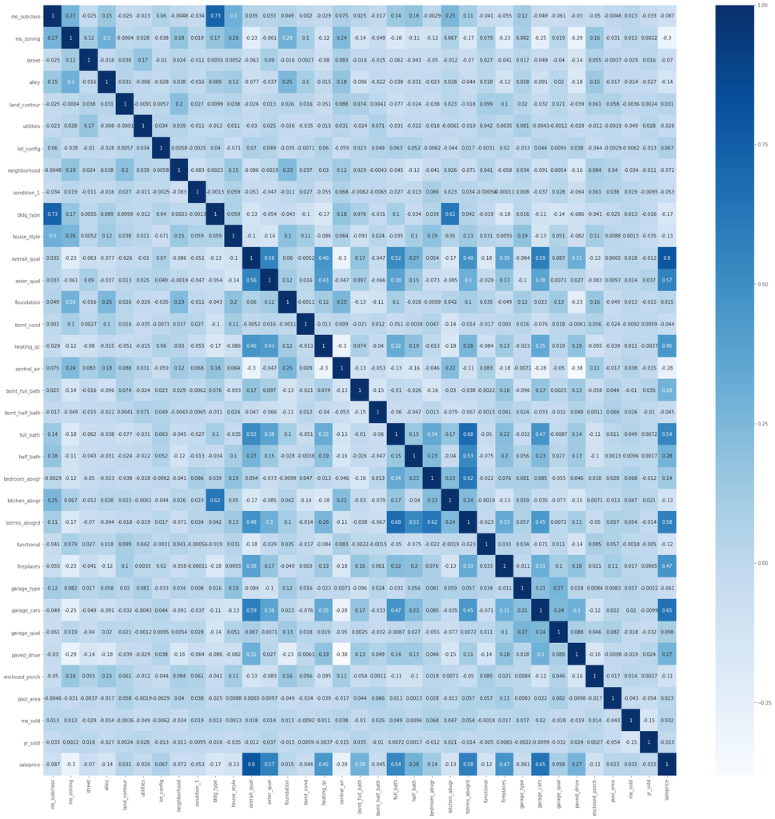

```python
sns.heatmap(df.corr(), annot=True, cmap="Blues")
```

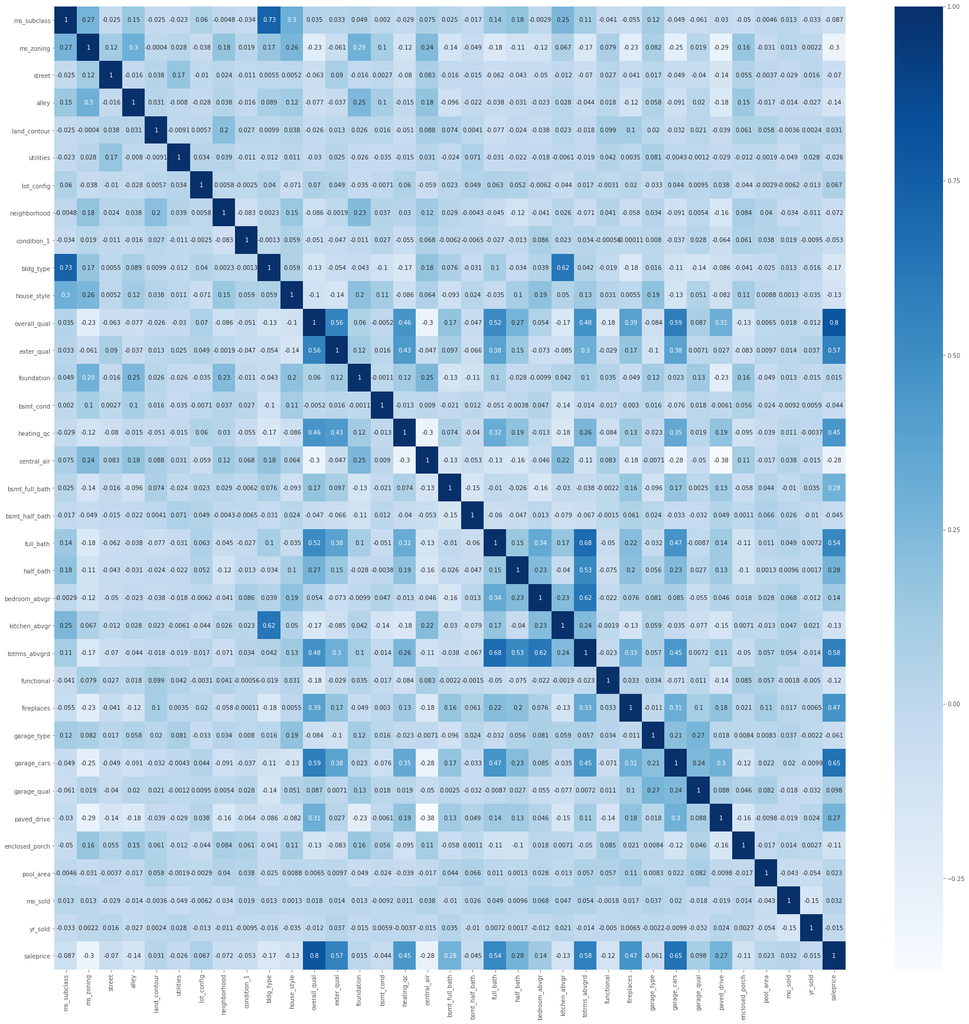

```python
sns.heatmap = sns.heatmap(df.corr(), annot=True, cmap="Blues")
sns.heatmap.figure.savefig("sns.heatmap.png")
```

**Analysis of Heatmap of the Correlation Matrix**

- Examine the map, the darker colors show correlation between columns. The objective of this output is to predict salesprice, columns that correlate best are garage_cars, fireplaces, totrms_abvgrd, full_bath, heating_qc, exter_qual & overall_qaul. These columns have a .45 correlation and higher.

**Create scatterplots & boxplots for each of the columns that correlate with sales price**

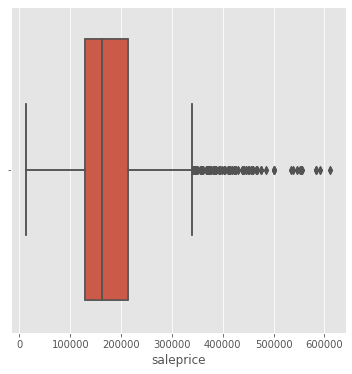

```python
plt.figure(figsize=(6,6))
sns.boxplot(df.saleprice)

boxplot_saleprice = sns.boxplot(df.saleprice)
boxplot_saleprice.figure.savefig("boxplot_saleprice.png")
```

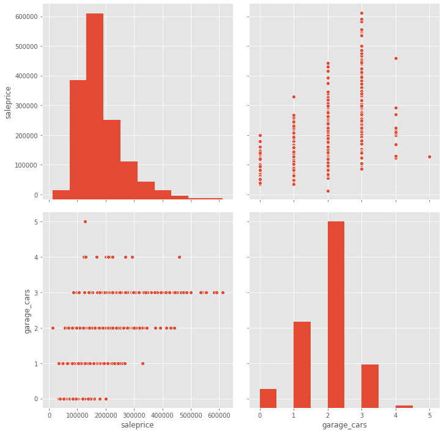

```python
sns.pairplot(df[df['saleprice'] >= 10000],
             vars = ['saleprice', 'garage_cars'],
             size = 5);
```

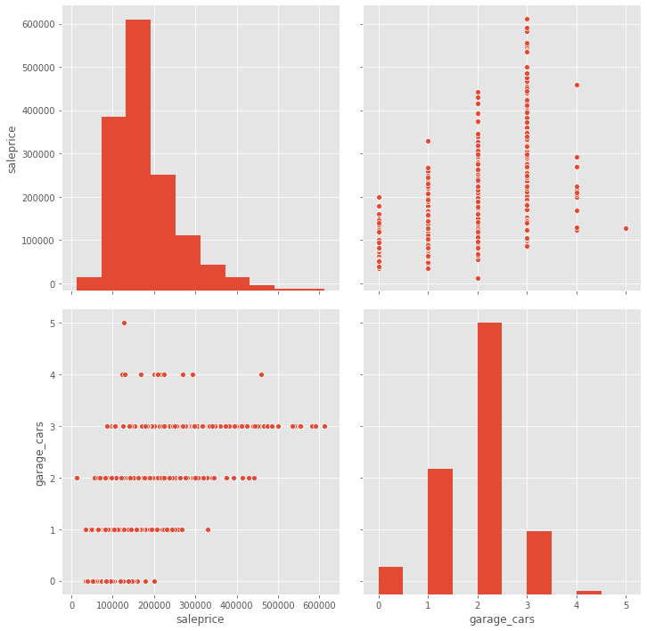

```python
pairplot_garage_cars = sns.pairplot(df[df['saleprice'] >= 10000],
             vars = ['saleprice', 'garage_cars'],
             size = 5);
pairplot_garage_cars.savefig("pairplot_garage_cars.png")
```

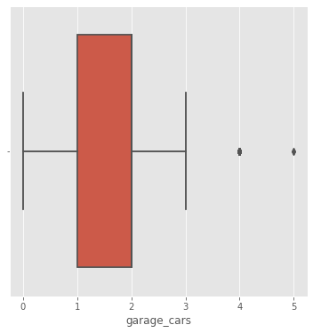

```python
plt.figure(figsize=(6,6))
sns.boxplot(df.garage_cars)

boxplot_garage_cars = sns.boxplot(df.garage_cars)
boxplot_garage_cars.figure.savefig("boxplot_garage_cars.png")
```

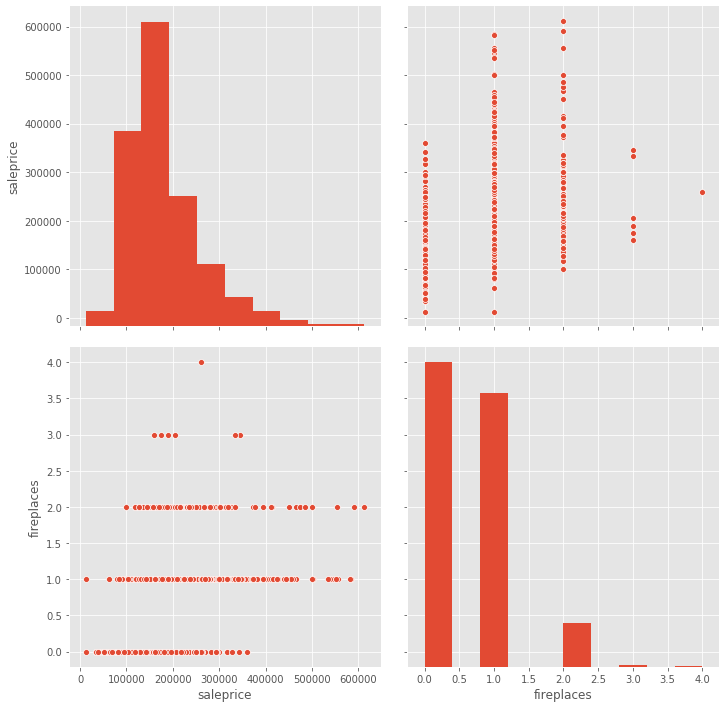

```python
sns.pairplot(df[df['saleprice'] >= 10000],
             vars = ['saleprice', 'fireplaces'],
             size = 5);
```

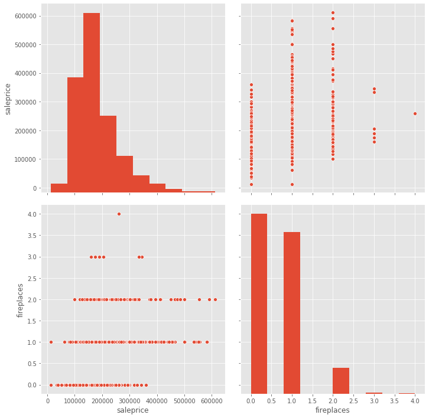

```python
pairplot_fireplaces = sns.pairplot(df[df['saleprice'] >= 10000],
             vars = ['saleprice', 'fireplaces'],
             size = 5);
pairplot_fireplaces.savefig("pairplot_fireplaces.png")
```

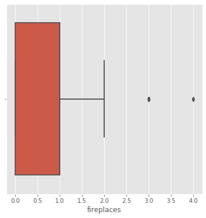

```python
plt.figure(figsize=(6,6))
sns.boxplot(df.fireplaces)

boxplot_fireplaces = sns.boxplot(df.fireplaces)
boxplot_fireplaces.figure.savefig("boxplot_fireplaces.png")
```

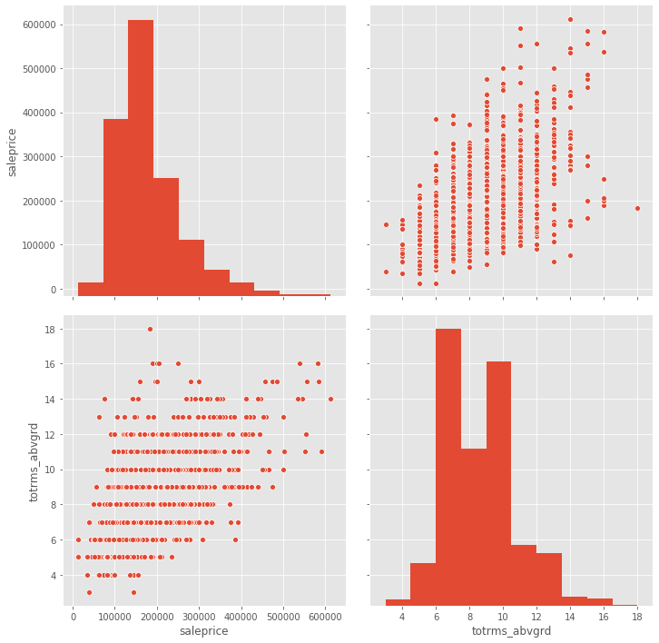

```python
sns.pairplot(df[df['saleprice'] >= 10000],
             vars = ['saleprice', 'totrms_abvgrd'],
             size = 5);
```

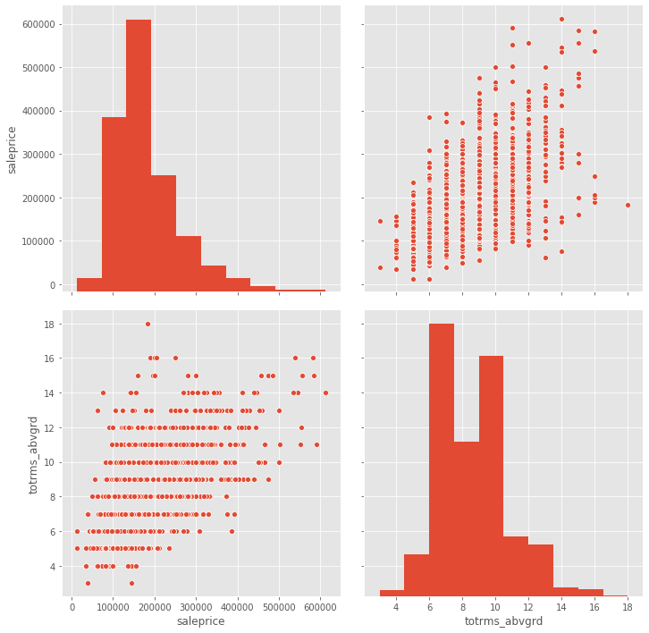

```python
pairplot_totrms_abvgrd = sns.pairplot(df[df['saleprice'] >= 10000],
             vars = ['saleprice', 'totrms_abvgrd'],
             size = 5);
pairplot_totrms_abvgrd.savefig("pairplot_totrms_abvgrd.png")
```

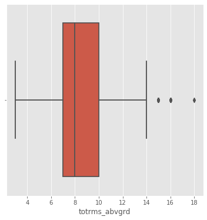

```python
plt.figure(figsize=(6,6))
sns.boxplot(df.totrms_abvgrd)

boxplot_totrms_abvgrd = sns.boxplot(df.totrms_abvgrd)
boxplot_totrms_abvgrd.figure.savefig("boxplot_totrms_abvgrd.png")
```

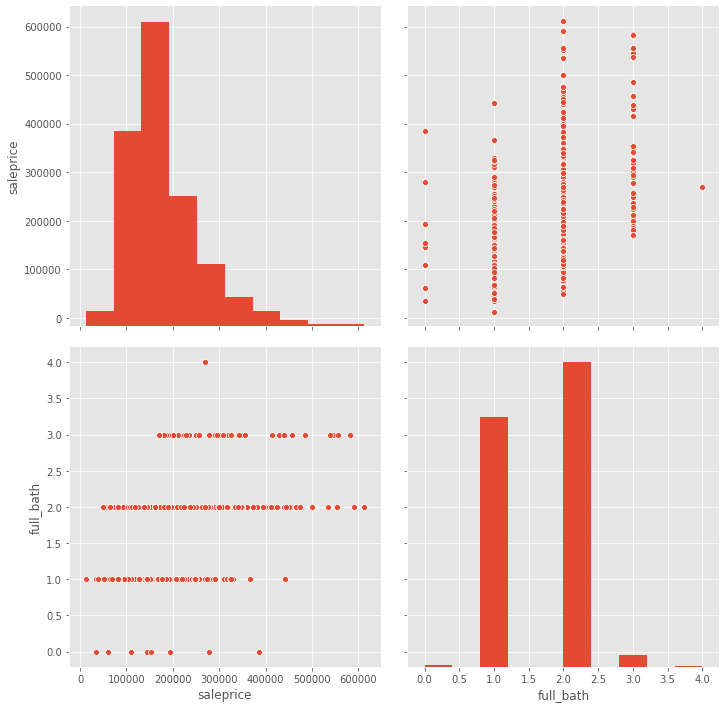

```python
sns.pairplot(df[df['saleprice'] >= 10000],
             vars = ['saleprice', 'full_bath'],
             size = 5);
```

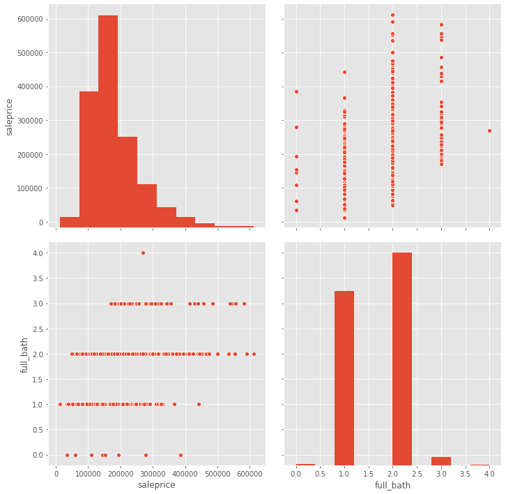

```python
pairplot_full_bath = sns.pairplot(df[df['saleprice'] >= 10000],
             vars = ['saleprice', 'full_bath'],
             size = 5);
pairplot_full_bath.savefig("pairplot_full_bath.png")
```

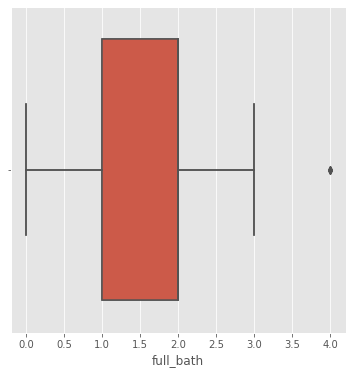

```python
plt.figure(figsize=(6,6))
sns.boxplot(df.full_bath)

boxplot_full_bath = sns.boxplot(df.full_bath)
boxplot_full_bath.figure.savefig("boxplot_full_bath.png")
```

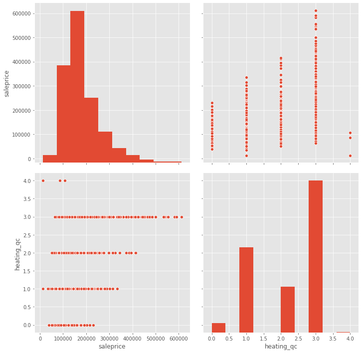

```python
sns.pairplot(df[df['saleprice'] >= 10000],
             vars = ['saleprice', 'heating_qc'],
             size = 5);
```

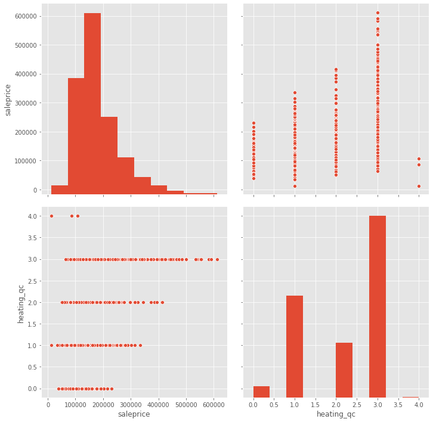

```python
pairplot_heating_qc = sns.pairplot(df[df['saleprice'] >= 10000],
             vars = ['saleprice', 'heating_qc'],
             size = 5);
pairplot_heating_qc.savefig("pairplot_heating_qc.png")
```

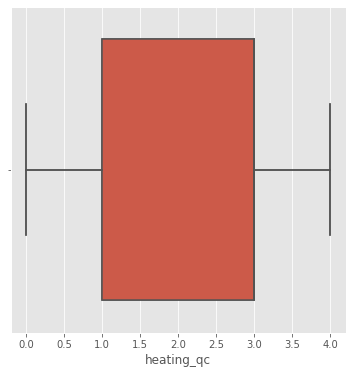

```python
plt.figure(figsize=(6,6))
sns.boxplot(df.heating_qc)

boxplot_heating_qc = sns.boxplot(df.heating_qc)
boxplot_heating_qc.figure.savefig("boxplot_heating_qc.png")
```

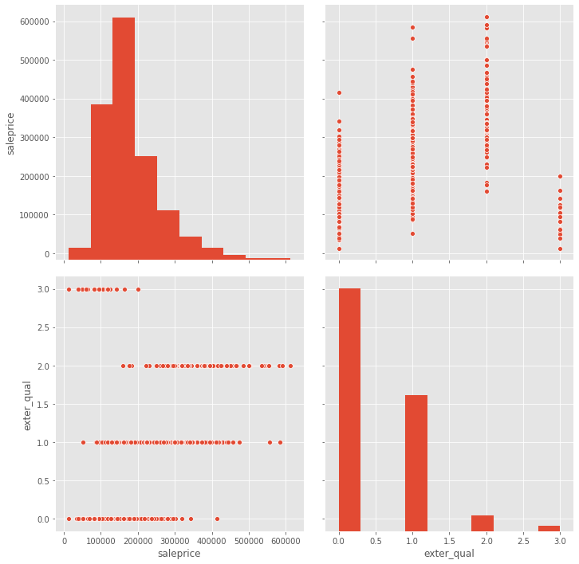

```python
sns.pairplot(df[df['saleprice'] >= 10000],
             vars = ['saleprice', 'exter_qual'],
             size = 5);
```

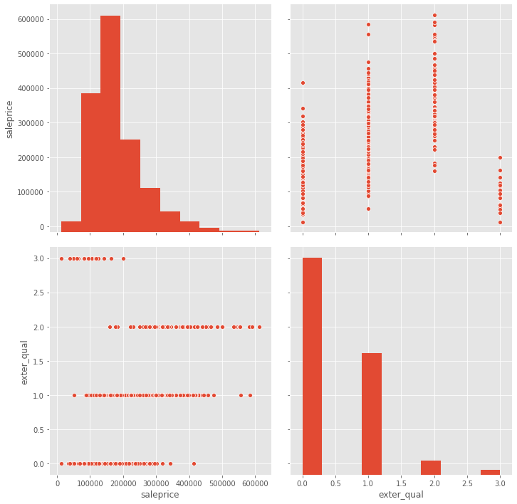

```python
pairplot_exter_qual = sns.pairplot(df[df['saleprice'] >= 10000],
             vars = ['saleprice', 'exter_qual'],
             size = 5);
pairplot_exter_qual.savefig("pairplot_exter_qual.png")
```

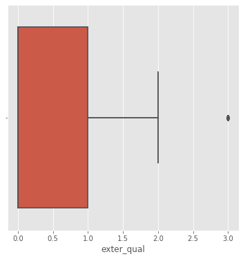

```python
plt.figure(figsize=(6,6))
sns.boxplot(df.exter_qual)

boxplot_exter_qual = sns.boxplot(df.exter_qual)
boxplot_exter_qual.figure.savefig("boxplot_exter_qual.png")
```

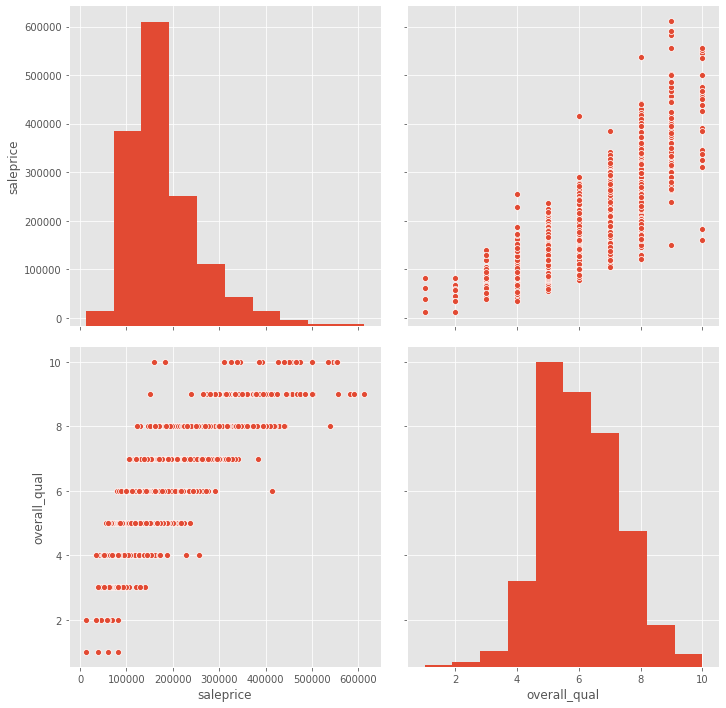

```python
sns.pairplot(df[df['saleprice'] >= 10000],
             vars = ['saleprice', 'overall_qual'],
             size = 5);
```

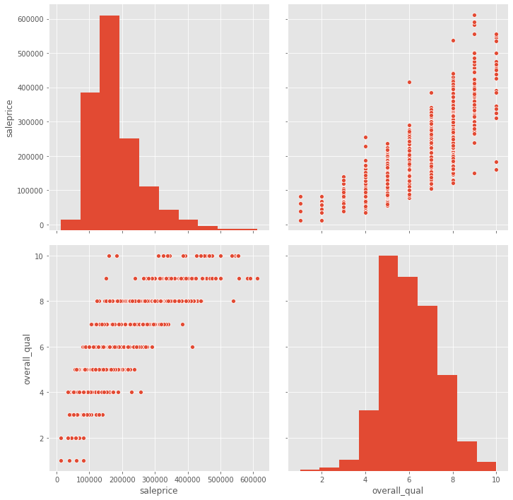

```python
pairplot_overall_qual = sns.pairplot(df[df['saleprice'] >= 10000],
             vars = ['saleprice', 'overall_qual'],
             size = 5);
pairplot_overall_qual.savefig("pairplot_overall_qual.png")
```

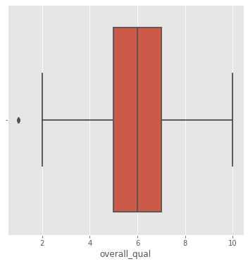

```python
plt.figure(figsize=(6,6))
sns.boxplot(df.overall_qual)

boxplot_overall_qual = sns.boxplot(df.overall_qual)
boxplot_overall_qual.figure.savefig("boxplot_overall_qual.png")
```

**Create our features matrix for the Train/Test Split Model**

```python
features = ['ms_subclass',
            'ms_zoning',
            'street',
            'alley',
            'land_contour',
            'utilities',
            'lot_config',
            'neighborhood',
            'condition_1',
            'bldg_type',
            'house_style',
            'overall_qual',
            'exter_qual',
            'foundation',
            'bsmt_cond',
            'heating_qc',
            'central_air',
            'bsmt_full_bath',
            'bsmt_half_bath',
            'full_bath',
            'half_bath',
            'bedroom_abvgr',
            'kitchen_abvgr',
            'totrms_abvgrd',
            'functional',
            'fireplaces',
            'garage_type',
            'garage_cars',
            'garage_qual',
            'paved_drive',
            'enclosed_porch',
            'pool_area',
            'mo_sold',
            'yr_sold']
X = df[features]
```

```python
y = df['saleprice']
```

**Train/Test Split Model**

```python
X_train, X_test, y_train, y_test = train_test_split(X, y, test_size=0.2)
```

```python
print(X_train.shape, y_train.shape)
print(X_test.shape, y_test.shape)
```

```
(1638, 34) (1638,)
(410, 34) (410,)
```

**Linear Regression model**

```python
lr = LinearRegression()
```

```python
model = lr.fit(X_train, y_train)
```

```python
y_train.shape
```

```
(1638,)
```

```python
X_train.shape
```

```
(1638, 34)
```

```python
model.fit(X, y)
```

```
LinearRegression(copy_X=True, fit_intercept=True, n_jobs=None,
         normalize=False)
```

```python
X_test.shape
```

```
(410, 34)
```

```python
predictions = lr.predict(X_test)
```

**Visualizing the fitting of a multiple linear regression model**

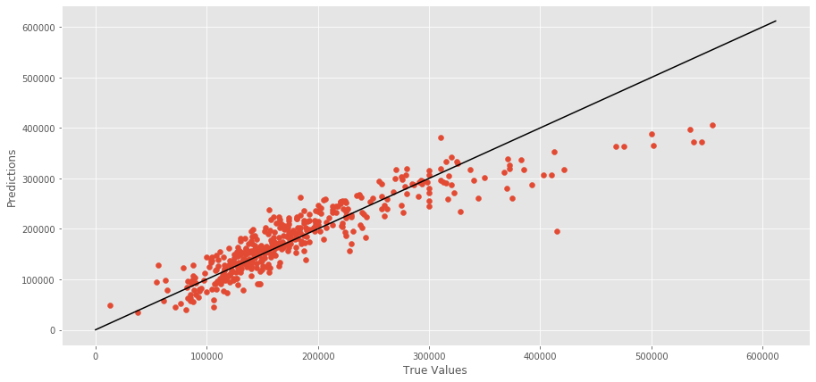

```python
plt.figure(figsize=(15,7))
plt.scatter(y_test, predictions)
plt.xlabel("True Values")
plt.ylabel("Predictions")
plt.plot([0, np.max(y)], [0, np.max(y)], c = 'k')
plt.show();
```

**What can this plot tell us about the model?**

```python
model.score(X_test, y_test)
```

```
0.810877102722986
```

**What can this score tell us about the model?**

- Closer to 1 desirable
- Not scale dependent.
- "A residual value of 0.8 means that 80% of the variability in the data are explained by our model, relative to a model with no predictors."
- As you add more variables, residuals will never decrease (with linear regression).

**K-Folds Cross Validation**

```python
kf = KFold(n_splits=5, random_state=42, shuffle=True)
```

```python
cross_val_score(lr, X_train, y_train, cv=kf)
```

```
array([0.81252181, 0.80490007, 0.81937067, 0.74338117, 0.73600725])
```

**What is K-Folds Cross Validation?**

- K-fold cross-validation takes the idea of a single train/test split and expands it to multiple tests across different train/test splits of your data.
- K-fold cross-validation builds K models — one for each train/test pair — and evaluates those models on each respective test set.
- The K-fold cross-validation scores appear to be in proximity to out model score indicating that our data is regular and redundant thus giving us confidence in its accuracy and precision.

**Load the test data:**

```python
df_test = pd.read_csv('../data/test_clean.csv')
```

**Describe the basic format:**

```python
df_test.shape
```

```
(879, 35)
```

```python
df_test.dtypes
```

```
Unnamed: 0        int64
ms_subclass       int64
ms_zoning         int64
street            int64
alley             int64
land_contour      int64
utilities         int64
lot_config        int64
neighborhood      int64
condition_1       int64
bldg_type         int64
house_style       int64
overall_qual      int64
exter_qual        int64
foundation        int64
bsmt_cond         int64
heating_qc        int64
central_air       int64
bsmt_full_bath    int64
bsmt_half_bath    int64
full_bath         int64
half_bath         int64
bedroom_abvgr     int64
kitchen_abvgr     int64
totrms_abvgrd     int64
functional        int64
fireplaces        int64
garage_type       int64
garage_cars       int64
garage_qual       int64
paved_drive       int64
enclosed_porch    int64
pool_area         int64
mo_sold           int64
yr_sold           int64
dtype: object
```

**Looks like an extra column has been added, column Unnamed: 0 will be dropped.**

```python
df_test = df_test.drop(columns=['Unnamed: 0'])
df_test.head(5)
```

|  | ms_subclass | ms_zoning | street | alley | land_contour | utilities | lot_config | neighborhood | condition_1 | bldg_type | ... | functional | fireplaces | garage_type | garage_cars | garage_qual | paved_drive | enclosed_porch | pool_area | mo_sold | yr_sold |
| --- | --- | --- | --- | --- | --- | --- | --- | --- | --- | --- | --- | --- | --- | --- | --- | --- | --- | --- | --- | --- | --- |
| 0 | 190 | 3 | 0 | 1 | 0 | 0 | 1 | 14 | 0 | 4 | ... | 0 | 0 | 2 | 1 | 5 | 1 | 112 | 0 | 4 | 2006 |
| 1 | 90 | 0 | 0 | 0 | 0 | 0 | 1 | 11 | 0 | 3 | ... | 0 | 0 | 1 | 2 | 1 | 1 | 0 | 0 | 8 | 2006 |
| 2 | 60 | 0 | 0 | 0 | 0 | 0 | 1 | 1 | 0 | 0 | ... | 0 | 1 | 1 | 2 | 1 | 1 | 0 | 0 | 9 | 2006 |
| 3 | 30 | 3 | 0 | 0 | 0 | 0 | 1 | 14 | 0 | 0 | ... | 0 | 0 | 2 | 2 | 2 | 0 | 184 | 0 | 7 | 2007 |
| 4 | 20 | 0 | 0 | 0 | 0 | 0 | 1 | 0 | 0 | 0 | ... | 0 | 2 | 1 | 2 | 1 | 1 | 0 | 0 | 7 | 2009 |

5 rows × 34 columns

**Predicting prices for text_cleaned data:**

```python
predictions_two = lr.predict(df_test)
```

```python
predictions_two
```

```
array([123456.81313363, 145523.69740388, 256828.64044622, 138252.62974197,
       205504.28870936,  49187.75898915,  78212.83605523, 108985.64944097,
       141606.9021482 , 190734.75113593, 158049.71622987, 135519.73620701,
       164197.74914698, 294651.15886655, 180969.40992982, 147108.54845702,
       149423.75850891, 125604.02149005, 199650.33225768, 216717.00897674,
       152768.73579684, 136894.67732304, 194718.48032213, 193359.29367337,
       194943.11981171,  99296.59432352, 106050.98837996, 100910.72216777,
       154428.4913497 ,  45941.83243958,  72310.72695017,  85132.74077717,
       219454.93455201, 143189.62710166, 219550.12681566, 166662.75230835,
       117420.27735287, 146997.73791915, 132253.30765768, 190267.35432381,
       131258.94936467, 257027.02830169, 164779.77992714, 172464.61728166,
       226225.2116743 ,  63247.38644113, 237970.45449705, 135549.29856919,
       121110.29107574, 118556.6292323 , 112754.60097125, 214870.27059906,
       268759.18002143, 117842.36132041,  97328.14792476, 161518.39605964,
       201999.71205148, 138602.07077422, 179722.09566368, 264619.79868402,
       272167.50033155, 108701.71507767, 157570.46818523, 177456.3420078 ,
       195440.38602431, 305267.28920889,  64502.46011379, 196644.17246432,
        61656.96879104, 157256.70327127, 103220.91916508, 311545.14438166,
       204591.42531047, 223643.73141717, 146091.77353047, 184259.09203801,
       407518.72210822, 166193.89367036, 147983.39831876, 106947.60311746,
       337590.09745411, 222141.79512363, 106444.19703186,  98252.16331571,
       126299.65114669, 201920.11334572, 304432.43046896, 134869.20622322,
       148265.44012185, 245361.17694054, 133285.00710233, 136430.12516037,
        90280.27053285, 122964.48306862, 239386.58393139, 124832.81403649,
       159707.41735131, 148519.7957079 , 236933.98776271, 215933.4115343 ,
       246072.83682893, 282209.154797  , 189710.28816049, 125426.85099973,
       386281.71885225, 167046.73247405,  74765.28310578, 173999.28577789,
       193610.50916904, 143513.23319145, 173597.6288698 , 205205.30567875,
       234078.92257654, 114796.56929916, 103044.18822565, 246436.86238016,
       377341.26862261, 106714.1137133 , 111692.86611355, 343629.02538475,
       184880.31780339, 351930.76731342, 275990.98865782, 289650.84249925,
       158775.79752016, 158420.61391001, 328967.52938883, 108139.54048275,
       144336.93188935, 131221.10187881, 288177.36493348, 139074.67254534,
       219493.78402838, 164693.13709494, 146832.66803562, 158419.34643565,
       239581.33263882, 193364.86985531, 195199.87354196, 197169.34862587,
       116278.18253981, 175283.08779743, 129868.40225805, 136828.2535934 ,
       178373.1798976 , 105775.78793438, 137395.06779919, 167432.3569151 ,
       135548.11639506,  28528.13987058, 211038.30244546, 214934.72283243,
       138864.28339084, 117428.82851165, 136546.44870939, 124612.06982723,
       136215.30653765,  38506.08273998, 141125.41285472, 275263.94821026,
```

[output cut: 165 more lines]

```
       157765.49191268, 195643.71683495, 100762.75123786, 324179.52746899,
       109498.74512475, 190843.24231765, 233769.06414451, 364087.5020396 ,
       141372.72224809, 150461.39865277, 153162.06744454, 192913.58362881,
       153189.81523539, 274943.27713413, 226035.87080687, 131605.22019099,
       137560.76804467, 294644.30163266, 121235.68607909, 120522.56509967,
       137756.62252253, 218177.84841496, 183995.60433993, 232059.18514156,
       131076.53505804, 184673.46324672, 170871.78429092, 207955.15542644,
       228322.46290684, 123469.03857824, 176070.96247828, 159445.48784462,
       182875.22960332, 147026.3251142 , 156874.42944072, 187952.6185745 ,
        81436.32778404, 197128.62270213,  52424.76684309, 227464.92396898,
       109851.89198129, 354300.55947618, 146574.84961081,  95864.28269358,
       167014.3229392 , 159143.63380955, 201733.7400665 , 212975.22219772,
       201713.09897466, 183687.7763829 , 166843.53217037, 271271.95756982,
       273181.30050098, 243434.95490598, 205831.39759332, 228606.9250008 ,
       116808.0858467 ,  96378.7823902 , 149323.12424398])
```

**Data generated is for lots in the test_clean.csv, let's see how it compares with sample_sub_reg.csv**

**Load the sample data:**

```python
df_sample = pd.read_csv('../data/sample_sub_reg.csv')
```

**Describe the basic format:**

```python
df_sample.shape
```

```
(879, 2)
```

```python
df_sample.dtypes
```

```
Id             int64
SalePrice    float64
dtype: object
```

```python
df_sample.head(5)
```

|  | Id | SalePrice |
| --- | --- | --- |
| 0 | 2 | 181479.1217 |
| 1 | 4 | 181479.1217 |
| 2 | 6 | 181479.1217 |
| 3 | 7 | 181479.1217 |
| 4 | 17 | 181479.1217 |

**It appears that sample_sub_reg data is a meaned price, let's mean our data and see how it compares**

```python
np.mean(predictions_two)
```

```
178590.4798535031
```

```python
pct_change = 100 * (181479.1217 - 178590.4798) / 178590.4798
```

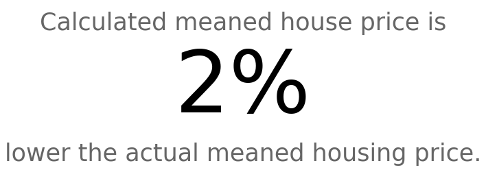

```python
plt.figure(figsize=(8, 5))

plt.text(x = 0.5,
         y = 0.9,
         s = 'Calculated meaned house price is',
         ha = 'center',
         va = 'center',
         size = 35,
         alpha = 0.6)

plt.text(x = 0.5,
         y = 0.55,
         s = str(round(pct_change)) + '%',
         ha = 'center',
         va = 'center',
         size = 125,
         alpha = 1)

plt.text(x = 0.5,
         y = 0.2,
         s = 'lower the actual meaned housing price.',
         ha = 'center',
         va = 'center',
         size = 35,
         alpha = 0.6)

plt.axis('off');
```